# Looping Statement

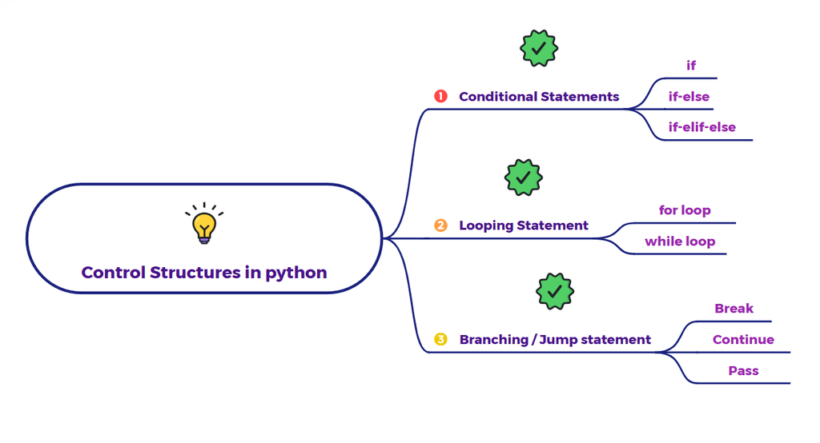

# 1. Control statement - Looping Statements (for loop: Iterates over a sequence (like a list, tuple, string, or range) or other iterable objects.)

### A. for loop - Iterating over a List

- fruits is a list of strings.
- The loop iterates through each element of the fruits list.
- In each iteration, the current element is assigned to the temporary variable fruit.
- The indented print statement inside the loop is executed for each fruit.

```python
# --- Example 1: Iterating over a List of fruits ---

fruits = ["apple", "banana", "cherry", "date"]

print("--- Eating fruits from the list ---")

# The 'for' loop will assign each item from 'fruits' to the variable 'fruit'
# in each iteration, until all items are processed.
for fruit in fruits:
    print(f"I am eating a {fruit}.") # This line is executed for each fruit

print("--- Finished eating fruits ---")
```

```
--- Eating fruits from the list ---
I am eating a apple.
I am eating a banana.
I am eating a cherry.
I am eating a date.
--- Finished eating fruits ---
```

### B. for loop - Iterating over a Tuple

- colors is a tuple of strings.
- The for loop processes each element of the colors tuple in sequence.

```python
# --- Example 2: Iterating over a Tuple of colors ---

colors = ("red", "green", "blue", "yellow")

print("\n--- Listing colors from the tuple ---")

# The loop assigns each color from 'colors' to 'color'
for color in colors:
    print(f"The color is {color}.")

print("--- Finished listing colors ---")
```

```
--- Listing colors from the tuple ---
The color is red.
The color is green.
The color is blue.
The color is yellow.
--- Finished listing colors ---
```

### C. for loop - Iterating over a String

- word is a string.
- The for loop treats the string as a sequence of characters and iterates through each character.

```python
# --- Example 3: Iterating over characters in a String ---

word = "Python"

print("\n--- Spelling out the word ---")

# The loop assigns each character from 'word' to 'char'
for char in word:
    print(f"Current character: {char}")

print("--- Finished spelling ---")
```

```
--- Spelling out the word ---
Current character: P
Current character: y
Current character: t
Current character: h
Current character: o
Current character: n
--- Finished spelling ---
```

### D. for loop - Iterating using range()

- range(stop): Generates numbers from 0 up to (but not including) stop.
- range(start, stop): Generates numbers from start up to (but not including) stop.
- range(start, stop, step): Generates numbers from start up to (but not including) stop, incrementing by step each time. A negative step counts downwards.

```python
# --- Example 4: Iterating using range() ---

print("\n--- Counting from 0 to 4 ---")
# range(5) generates numbers 0, 1, 2, 3, 4
for i in range(5):
    print(f"Count: {i}")

print("\n--- Counting from 1 to 5 (inclusive) ---")
# range(1, 6) generates numbers 1, 2, 3, 4, 5
for j in range(1, 6):
    print(f"Count: {j}")

print("\n--- Counting down from 10 by 2s ---")
# range(10, 0, -2) generates numbers 10, 8, 6, 4, 2
for k in range(10, 0, -2):
    print(f"Countdown: {k}")

print("--- Finished counting ---")
```

```
--- Counting from 0 to 4 ---
Count: 0
Count: 1
Count: 2
Count: 3
Count: 4

--- Counting from 1 to 5 (inclusive) ---
Count: 1
Count: 2
Count: 3
Count: 4
Count: 5

--- Counting down from 10 by 2s ---
Countdown: 10
Countdown: 8
Countdown: 6
Countdown: 4
Countdown: 2
--- Finished counting ---
```

# 2. Control statement - Looping Statements (while loop: Continues to execute a block of code as long as a specified condition remains true.)

- countdown_number = 5: We initialize our countdown_number to 5. This is crucial; without it, the while loop wouldn't know where to start.
- while countdown_number > 0:: This is our loop's condition.
  - Iteration 1: 5 > 0 is True. The loop body executes. countdown_number becomes 4.
  - Iteration 2: 4 > 0 is True. The loop body executes. countdown_number becomes 3.
  - ...
  - Iteration 5: 1 > 0 is True. The loop body executes. countdown_number becomes 0.
  - After Iteration 5: The loop goes back to check the condition. 0 > 0 is now False. The loop terminates.
- countdown_number -= 1: This line is the update step. It's vital! If we didn't decrement countdown_number, it would always be 5, and 5 > 0 would always be True, leading to an infinite loop.

```python
# --- Example 1: Simple Countdown ---

# 1. Initialization: Set the starting value for the counter
countdown_number = 5

print("--- Starting countdown ---")

# 2. Condition: The loop continues as long as countdown_number is greater than 0
while countdown_number > 0:
    # 3. Code Block: These lines are executed in each iteration
    print(f"Countdown: {countdown_number}")

    # 4. Update: Decrement the counter to eventually make the condition False
    countdown_number -= 1 # This is equivalent to countdown_number = countdown_number - 1

print("--- Blast Off! ---")
print(f"Final value of countdown_number: {countdown_number}")
```

```
--- Starting countdown ---
Countdown: 5
Countdown: 4
Countdown: 3
Countdown: 2
Countdown: 1
--- Blast Off! ---
Final value of countdown_number: 0
```